# Experiment 3

```python
%matplotlib widget

import pandas as pd
import numpy as np
import matplotlib
import matplotlib.pyplot as plt
from SSA_Decomposition import ssa_decomposition

font = {'size': 12}
matplotlib.rc('font', **font)
```

```python
# The PPG signal (sampled at 25Hz)
data_csv = pd.read_csv('ppg.csv')
fs = 25
# Extract ppg and acceleromter signals between 200s and 400s
ppg = data_csv['ppg'][200*fs:400*fs].to_numpy()
acc_x = data_csv['acc_x'][200*fs:400*fs].to_numpy()
acc_y = data_csv['acc_y'][200*fs:400*fs].to_numpy()
acc_z = data_csv['acc_z'][200*fs:400*fs].to_numpy()
acc_norm = np.sqrt(acc_x*acc_x+acc_y*acc_y+acc_z*acc_z)

time = np.arange(0, len(ppg)/fs, 1/fs)
```

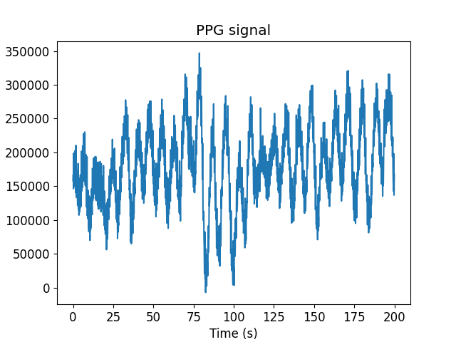

```python
# Plot data
fig = plt.figure()
plt.plot(time, ppg)
plt.title('PPG signal')
plt.ylabel('PPG')
plt.xlabel('Time (s)')
```

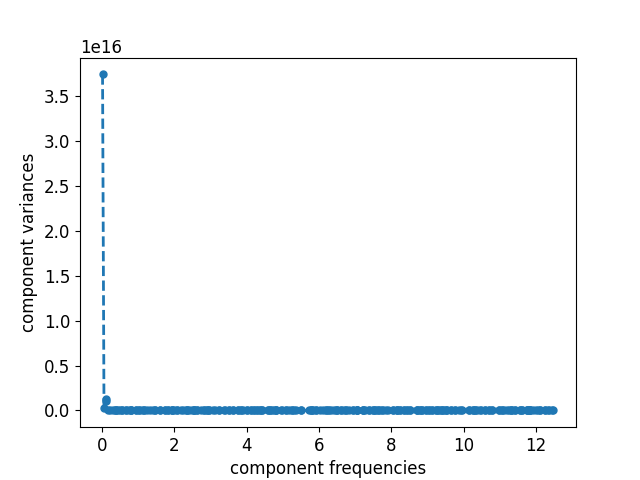

```python
# First SSA decomposition to extract long term drift
# Find the length L in samples, so that SVD first component corresponds to
# long term drift signal.
L = 10*fs
Y_1, fc_1, sig_1 = ssa_decomposition(ppg, L, fs, 2)
```

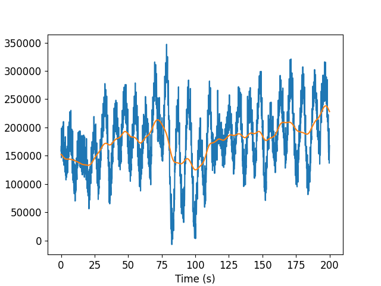

```python
# Plot signal and its baseline
fig = plt.figure()
plt.plot(time, ppg)
plt.plot(time, Y_1[:, 0].flatten(), label='baseline')
plt.ylabel('PPG')
plt.xlabel('Time (s)')
```

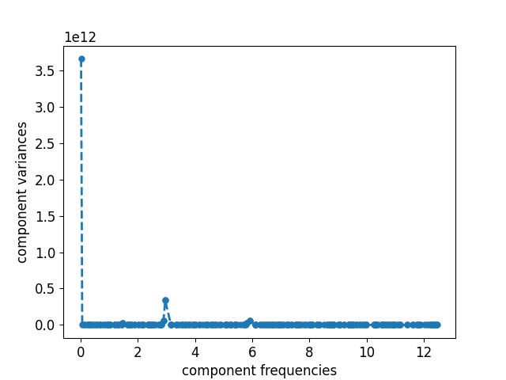

```python
# First SSA decomposition to extract long term drift from accelerometer
Y_acc1, fc_acc1, sig_acc1 = ssa_decomposition(acc_norm, L, fs, 2)
```

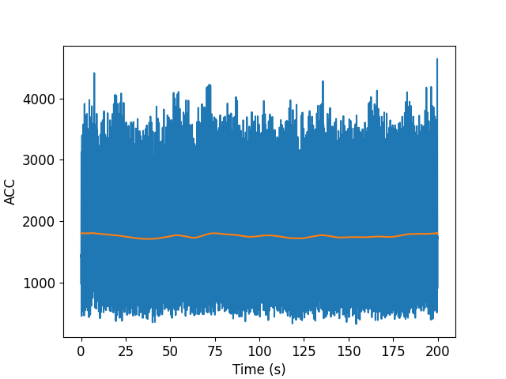

```python
fig = plt.figure()
plt.plot(time, acc_norm)
plt.plot(time, Y_acc1[:, 0].flatten(), label='baseline')
plt.ylabel('ACC')
plt.xlabel('Time (s)')
```

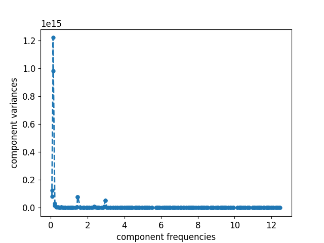

```python
# Remove First component
filt_x = ppg - Y_1[:, 0]
# Apply SSA on signal without baseline
# Set L to identify and remove respiration component
Y_2, fc_2, sig_2 = ssa_decomposition(filt_x, L, fs, 2)
```

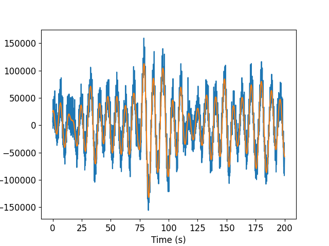

```python
# Find components characterizing respiration
resp_components = [0, 1, 2, 3]
fig = plt.figure()
plt.plot(time, filt_x)
plt.plot(time, np.sum(Y_2[:, resp_components], axis=1), label='Respiration')
plt.ylabel('PPG')
plt.xlabel('Time (s)')
```

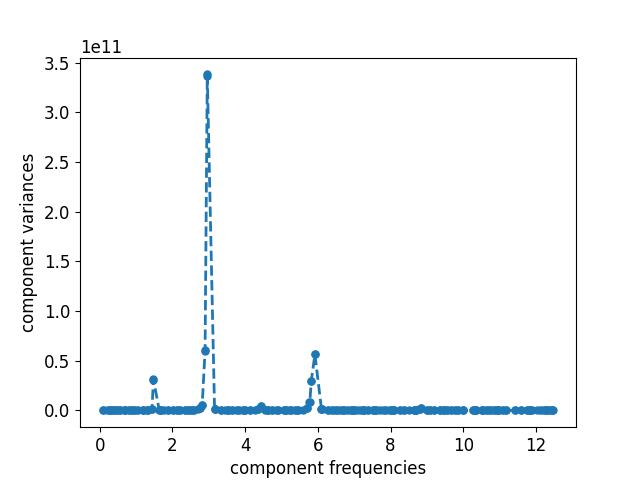

```python
# Remove First component
filt_acc = acc_norm - Y_acc1[:, 0]
# Apply SSA on accelerometer norm without baseline
Y_acc2, fc_acc2, sig_acc2 = ssa_decomposition(filt_acc, L, fs, 2)
```

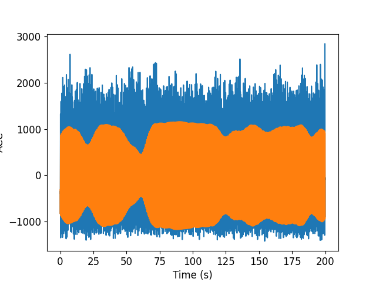

```python
# Find components characterizing respiration
cadence_components = [0, 1]
fig = plt.figure()
plt.plot(time, filt_acc)
plt.plot(time, np.sum(Y_acc2[:, cadence_components], axis=1), label='Cadence')
plt.ylabel('ACC')
plt.xlabel('Time (s)')
```

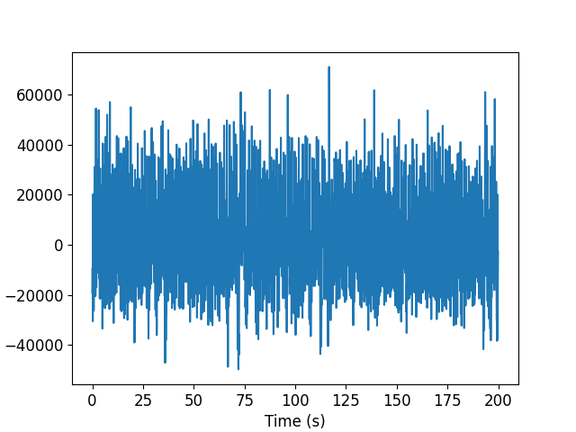

```python
# Remove respiration component(s)
filt_x2 = filt_x - np.sum(Y_2[:, resp_components], 1)
fig = plt.figure()
plt.plot(time, filt_x2)
plt.ylabel('PPG')
plt.xlabel('Time (s)')
```

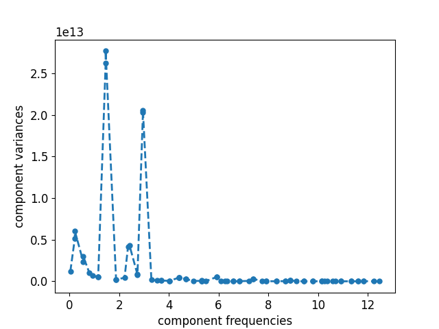

```python
# Apply SSA on signal without baseline, nor respiration
# Set L to identify running cadence and heart rate
Y_3, fc_3, sig_3 = ssa_decomposition(filt_x2, 80, fs, 2)
```

# QUESTION #3.1: Drift cancellation

Our window length is L = 10*fs. We can see on figure 2 that the first component we obtained corresponds to the long-term drift on both ppg and accelerometer signals. In figure 3, we can see that the curve of first component (orange curve) follows the baseline of the raw signal (blue curve)

# QUESTION #3.2: Respiration and cadence components extraction

b) The component related to the cadence in the accelerometer signal are plotted on figure 8 and we can see on the graph that the component with the strongest peak (so the strongest variance is about 3 Hz which correspond to the cadence of C= 3*60= 180 steps per minute.

c) At 1.5Hz, the first component corresponds to the movement of balancing of the arm. We can affirm this as its variance is smaller and its also acquiring by the accelerometer on the wrist. At 6Hz, the component correspond to the second harmonic of the cadence. The frequency is also the double of frequency of the cadence component.

# QUESTION #3.3: Heart rate estimation

Four components are present in figure 11 that are low frequency component (<0.5 Hz), 1.5 components, approximately 2.5 Hz components and 3Hz components. The respiration with the baseline corresponds to the low frequency components. We know from previously that the cadence and the arm movement correspond to 3Hz and 1.5Hz respectively. Therefore the heart rate component corresponds to the 2.5Hz components. The heart rate is then 2.5*60 = 150 bpm.